# **Milestone 1**

### **Multivariate Analysis**

#### Analyze Correlation Heatmap for Numerical Variables

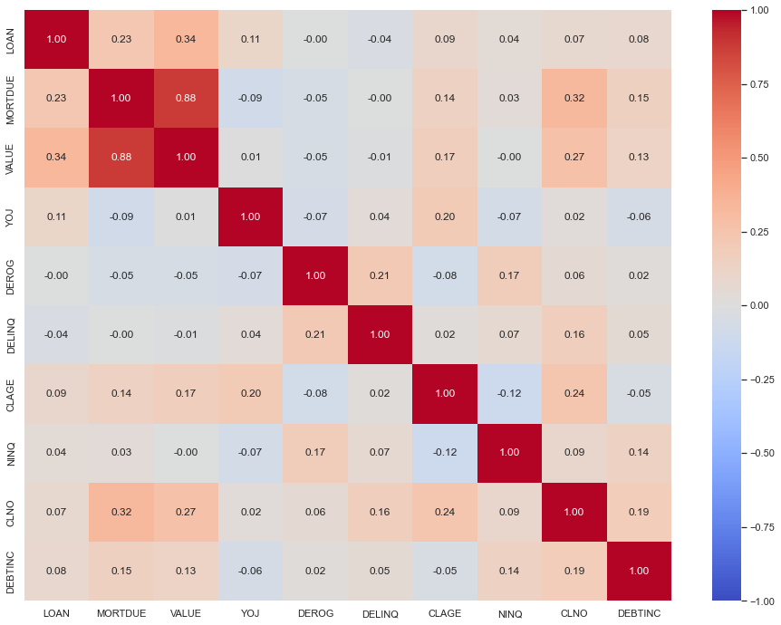

```python
# Separating numerical variables
numerical_col = data.select_dtypes(include=np.number).columns.tolist()

# Build correlation matrix for numerical columns
# Remove ___________ and complete the code

corr = data[numerical_col].corr()

# plot the heatmap
# Remove ___________ and complete the code

plt.figure(figsize=(16,12))

sns.heatmap(corr,cmap='coolwarm',vmax=1,vmin=-1, annot = True,
        fmt=".2f",
        xticklabels=corr.columns,
        yticklabels=corr.columns);
plt.show()
```

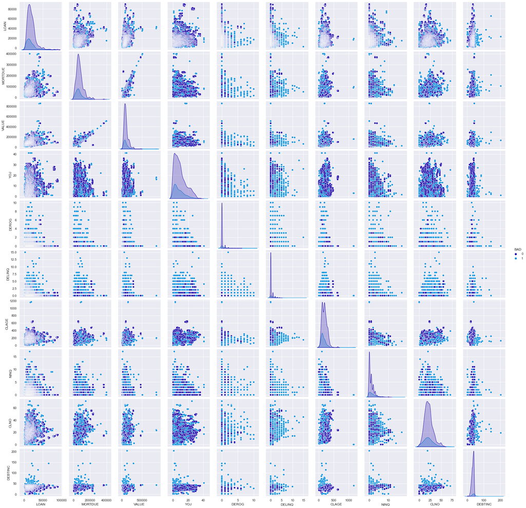

```python
# Build pairplot for the data with hue = 'BAD'
# Remove ___________ and complete the code

sns.pairplot(data, hue ='BAD')
plt.show()
```

### **Think about it**

- Are there missing values and outliers in the dataset? If yes, how can you treat them?
- Can you think of different ways in which this can be done and when to treat these outliers or not?
- Can we create new features based on Missing values?

#### Treating Outliers

```python
def treat_outliers(df,col):
    '''
    treats outliers in a varaible
    col: str, name of the numerical varaible
    df: data frame
    col: name of the column
    '''

    Q1 = df[col].quantile(0.25) # 25th quantile
    Q3 = df[col].quantile(0.75)  # 75th quantile
    IQR = Q3 -Q1  # IQR Range
    Lower_Whisker = Q1 - 1.5 * IQR  #define lower whisker
    Upper_Whisker = Q3 - 1.5 * IQR  # define upper Whisker
    df[col] = np.clip(df[col], Lower_Whisker, Upper_Whisker) # all the values samller than Lower_Whisker will be assigned value of Lower_whisker
                                                            # and all the values above upper_whishker will be assigned value of upper_Whisker
    return df

def treat_outliers_all(df, col_list):
    '''
    treat outlier in all numerical varaibles
    col_list: list of numerical varaibles
    df: data frame
    '''
    for c in col_list:
        df = treat_outliers(df,c)

    return df
```

```python
df_raw = data.copy()

numerical_col = df_raw.select_dtypes(include=np.number).columns.tolist()# getting list of numerical columns

df = treat_outliers_all(df_raw,numerical_col)
```

#### Adding new columns in the dataset for each column which has missing values

```python
#For each column we create a binary flag for the row, if there is missing value in the row, then 1 else 0.
def add_binary_flag(df,col):
    '''
    df: It is the dataframe
    col: it is column which has missing values
    It returns a dataframe which has binary falg for missing values in column col
    '''
    new_col = str(col)
    new_col += '_missing_values_flag'
    df[new_col] = df[col].isna()
    return df
```

```python
# list of columns that has missing values in it
missing_col = [col for col in df.columns if df[col].isnull().any()]

for colmn in missing_col:
    add_binary_flag(df,colmn)
```

#### Filling missing values in numerical columns with median and mode in categorical variables

```python
#  Treat Missing values in numerical columns with median and mode in categorical variables
# Select numeric columns.
num_data = df.select_dtypes('number')

# Select string and object columns.
cat_data = df.select_dtypes('category').columns.tolist()#df.select_dtypes('object')

# Fill numeric columns with median.
# Remove _________ and complete the code
df[num_data.columns] = num_data.fillna(num_data.median())

# Fill object columns with model.
# Remove _________ and complete the code
for column in cat_data:
    mode = df[column].mode()[0]
    df[column] = df[column].fillna(mode)
```

```python
df.info()
```

```
<class 'pandas.core.frame.DataFrame'>
RangeIndex: 5960 entries, 0 to 5959
Data columns (total 24 columns):
 #   Column                       Non-Null Count  Dtype
---  ------                       --------------  -----
 0   BAD                          5960 non-null   category
 1   LOAN                         5960 non-null   float64
 2   MORTDUE                      5960 non-null   float64
 3   VALUE                        5960 non-null   float64
 4   REASON                       5960 non-null   category
 5   JOB                          5960 non-null   category
 6   YOJ                          5960 non-null   float64
 7   DEROG                        5960 non-null   float64
 8   DELINQ                       5960 non-null   float64
 9   CLAGE                        5960 non-null   float64
```

[output cut: 16 more lines]

## **Proposed approach**

**1. Potential techniques** - What different techniques should be explored?

```
> I would like to explore the logistical regression model, decision tree model, and random forest model to see which model would do best in both training and testing datasets.
```

**2. Overall solution design** - What is the potential solution design?

[output not shown]

forest, etc.) to conclude which does the best at predicting with the dataset and which would be also most interpretable for the stakeholders as one of the objectives is to simplify and make this process more efficient. There are pros and cons to the various models for this problem so they must all be tested in order to find out the best model and solution design.

**3. Measures of success** - What are the key measures of success?

```
> Model that does best in both training and testing datasets, high precision and recall rate (low rate of false positives and false negatives), identifies important features, and reduces the effort and time required for the loan approval process and minimizes human error and bias
```

# **Milestone 2**

## **Model Building - Approach**

1. Data preparation
2. Partition the data into train and test set
3. Fit on the train data
4. Tune the model and prune the tree, if required
5. Test the model on test set

## **Data Preparation**

### **Separating the target variable from other variables**

```python
# Drop the dependent variable from the dataframe and create the X(independent variable) matrix
# Remove _________ and complete the code
X = df.drop(columns = 'BAD')

# Create dummy variables for the categorical variables - Hint: use the get_dummies() function
# Remove _________ and complete the code
X = pd.get_dummies(X, drop_first = True)

# Create y(dependent varibale)
# Remove _________ and complete the code
y = df['BAD']
```

### **Splitting the data into 70% train and 30% test set**

```python
# Split the data into training and test set
# Remove _________ and complete the code


X_train, X_test, y_train, y_test = train_test_split(X, y, test_size = 0.30, random_state = 1)
```

### **Think about it**

- You can try different splits like 70:30 or 80:20 as per your choice. Does this change in split affect the performance?
- If the data is imbalanced, can you make the split more balanced and if yes, how?

## **Model Evaluation Criterion**

#### After understanding the problem statement, think about which evaluation metrics to consider and why.

```python
#creating metric function
def metrics_score(actual, predicted):
    print(classification_report(actual, predicted))
    cm = confusion_matrix(actual, predicted)
    plt.figure(figsize=(8,5))
    sns.heatmap(cm, annot=True,  fmt='.2f', xticklabels=['Not Eligible', 'Eligible'], yticklabels=['Not Eligible', 'Eligible'])
    plt.ylabel('Actual')
    plt.xlabel('Predicted')
    plt.show()
```

### **Build a Logistic Regression Model**

```python
# Defining the Logistic regression model
# Remove _________ and complete the code
lg = LogisticRegression()

# Fitting the model on the training data
# Remove _________ and complete the code

lg.fit(X_train,y_train)
```

```
LogisticRegression()
```

#### Checking the performance on the train dataset

```
              precision    recall  f1-score   support

           0       0.83      0.98      0.89      3355
           1       0.61      0.15      0.24       817

    accuracy                           0.81      4172
   macro avg       0.72      0.56      0.57      4172
weighted avg       0.78      0.81      0.77      4172
```

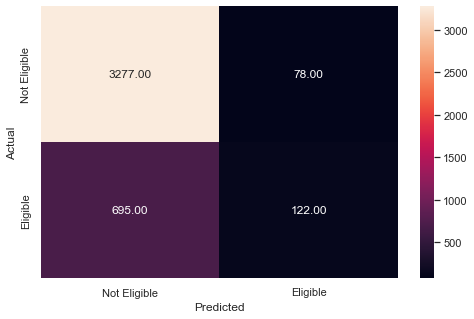

```python
#Predict for train set

y_pred_train = lg.predict(X_train)

#checking the performance on the train dataset

metrics_score(y_train, y_pred_train)
```

#### Checking the performance on the test dataset

```
              precision    recall  f1-score   support

           0       0.81      0.98      0.89      1416
           1       0.61      0.13      0.21       372

    accuracy                           0.80      1788
   macro avg       0.71      0.55      0.55      1788
weighted avg       0.77      0.80      0.75      1788
```

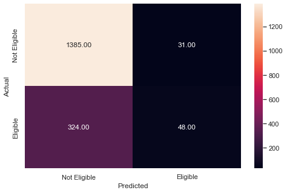

```python
#Predict for test set

y_pred_test = lg.predict(X_test)


#checking the performance on the test dataset

metrics_score(y_test, y_pred_test)
```

**Observations:

- Accuracy level is at around 80% for both training and testing data but accuracy is not a good metric since we have an uneven dataset. F1 score is extremely low, especially the recall which is extremely important so this model isn't doing well.

#### Let's check the coefficients, and check which variables are important and how they affect the process of loan approval

```python
# Printing the coefficients of logistic regression
# Remove _________ and complete the code

cols = X.columns

coef_lg = lg.coef_

pd.DataFrame(coef_lg,columns = cols).T.sort_values(by = 0, ascending = False)
```

|  | 0 |
| --- | --- |
| DEBTINC | 0.625389 |
| DEBTINC_missing_values_flag | 0.593117 |
| VALUE_missing_values_flag | 0.092583 |
| JOB_Other | 0.050882 |
| REASON_HomeImp | 0.029245 |
| JOB_Self | 0.019571 |
| CLAGE_missing_values_flag | 0.017581 |
| JOB_Sales | 0.017572 |
| CLNO_missing_values_flag | 0.006397 |
| DEROG | 0.000000 |
| DELINQ | 0.000000 |
| MORTDUE | -0.000015 |
| VALUE | -0.000080 |
| REASON_missing_values_flag | -0.000591 |
| LOAN | -0.001790 |
| MORTDUE_missing_values_flag | -0.008940 |
| NINQ | -0.016232 |
| YOJ | -0.032465 |
| NINQ_missing_values_flag | -0.035775 |
| CLAGE | -0.036153 |
| JOB_missing_values_flag | -0.040582 |
| YOJ_missing_values_flag | -0.045248 |
| JOB_ProfExe | -0.049637 |
| DELINQ_missing_values_flag | -0.050049 |
| JOB_Office | -0.059238 |
| DEROG_missing_values_flag | -0.069087 |
| CLNO | -0.259962 |

**Insights

Finding the Odds

```python
odds = np.exp(lg.coef_[0]) # Finding the odds

# Adding the odds to a DataFrame and sorting the values
pd.DataFrame(odds, X_train.columns, columns = ['odds']).sort_values(by = 'odds', ascending = False)
```

|  | odds |
| --- | --- |
| DEBTINC | 1.868973 |
| DEBTINC_missing_values_flag | 1.809620 |
| VALUE_missing_values_flag | 1.097004 |
| JOB_Other | 1.052199 |
| REASON_HomeImp | 1.029676 |
| JOB_Self | 1.019764 |
| CLAGE_missing_values_flag | 1.017736 |
| JOB_Sales | 1.017728 |
| CLNO_missing_values_flag | 1.006417 |
| DEROG | 1.000000 |
| DELINQ | 1.000000 |
| MORTDUE | 0.999985 |
| VALUE | 0.999920 |
| REASON_missing_values_flag | 0.999410 |
| LOAN | 0.998212 |
| MORTDUE_missing_values_flag | 0.991100 |
| NINQ | 0.983899 |
| YOJ | 0.968056 |
| NINQ_missing_values_flag | 0.964857 |
| CLAGE | 0.964492 |
| JOB_missing_values_flag | 0.960230 |
| YOJ_missing_values_flag | 0.955761 |
| JOB_ProfExe | 0.951575 |
| DELINQ_missing_values_flag | 0.951183 |
| JOB_Office | 0.942482 |
| DEROG_missing_values_flag | 0.933245 |
| CLNO | 0.771081 |

Insights:

### **Think about it:**

- The above Logistic regression model was build on the threshold of 0.5, can we use different threshold?
- How to get an optimal threshold and which curve will help you achieve?
- How does, accuracy, precision and recall change on the threshold?

Precision Recall Curve Graph

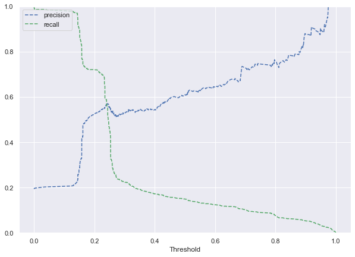

```python
y_scores_lg = lg.predict_proba(X_train) # predict_proba gives the probability of each observation belonging to each class


precisions_lg, recalls_lg, thresholds_lg = precision_recall_curve(y_train, y_scores_lg[:, 1])

# Plot values of precisions, recalls, and thresholds
plt.figure(figsize = (10, 7))

plt.plot(thresholds_lg, precisions_lg[:-1], 'b--', label = 'precision')

plt.plot(thresholds_lg, recalls_lg[:-1], 'g--', label = 'recall')

plt.xlabel('Threshold')

plt.legend(loc = 'upper left')

plt.ylim([0, 1])

plt.show()
```

The precision and recall are balanced at a threshold of about 0.25. I would like to see how it performs with this threshold.

```
              precision    recall  f1-score   support

           0       0.87      0.91      0.89      3355
           1       0.55      0.45      0.50       817

    accuracy                           0.82      4172
   macro avg       0.71      0.68      0.70      4172
weighted avg       0.81      0.82      0.81      4172
```

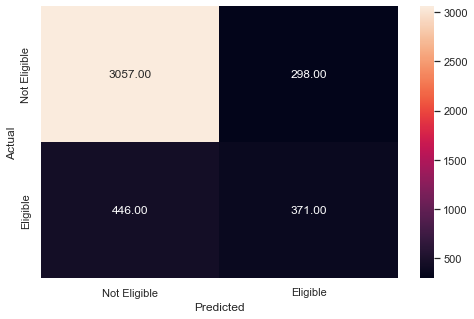

```python
optimal_threshold1 = .25

y_pred_train = lg.predict_proba(X_train)

metrics_score(y_train, y_pred_train[:, 1] > optimal_threshold1)
```

```
              precision    recall  f1-score   support

           0       0.86      0.92      0.89      1416
           1       0.57      0.43      0.49       372

    accuracy                           0.81      1788
   macro avg       0.72      0.67      0.69      1788
weighted avg       0.80      0.81      0.80      1788
```

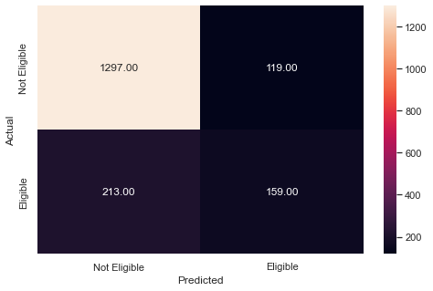

```python
optimal_threshold1 = .25

y_pred_test = lg.predict_proba(X_test)

metrics_score(y_test, y_pred_test[:, 1] > optimal_threshold1)
```

Insights:

- Testing dataset follows training pretty well but again, recall and precision is not at an ideal high value that it needs to be.

### **Build a Decision Tree Model**

### **Think about it:**

- In Logistic regression we treated the outliers and built the model, should we do the same for tree based models or not? If not, why?

#### Data Preparation for the tree based model

```python
# Add binary flags
# List of columns that has missing values in it

missing_col = [col for col in data.columns if data[col].isnull().any()]

for colmn in missing_col:
    add_binary_flag(data,colmn)
```

```python
#  Treat Missing values in numerical columns with median and mode in categorical variables
# Select numeric columns.
num_data = data.select_dtypes('number')

# Select string and object columns.
cat_data = data.select_dtypes('category').columns.tolist() #df.select_dtypes('object')

# Fill numeric columns with median.
# Remove _________ and complete the code
data[num_data.columns] = num_data.fillna(num_data.median())


# Fill object columns with mode.
# Remove _________ and complete the code
for column in cat_data:
    mode = data[column].mode()[0]
    data[column] = data[column].fillna(mode)
```

#### Separating the target variable y and independent variable x

```python
# Drop dependent variable from dataframe and create the X(independent variable) matrix
# Remove _________ and complete the code

X = data.drop(columns = 'BAD')

# Create dummy variables for the categorical variables - Hint: use the get_dummies() function
# Remove _________ and complete the code
X = pd.get_dummies(X, drop_first = True)

# Create y(dependent varibale)
# Remove _________ and complete the code

y = data['BAD']
```

#### Split the data

```python
# Split the data into training and test set
# Remove _________ and complete the code

X_train, X_test, y_train, y_test = train_test_split(X, y, test_size = 0.30, random_state = 1)
```

```python
#Defining Decision tree model with class weights class_weight={0: 0.2, 1: 0.8}
# Remove ___________ and complete the code

dt = DecisionTreeClassifier(class_weight = {0: 0.2, 1: 0.8}, random_state = 1)
```

```python
#fitting Decision tree model
# Remove ___________ and complete the code
dt.fit(X_train, y_train)
```

```
DecisionTreeClassifier(class_weight={0: 0.2, 1: 0.8}, random_state=1)
```

#### Checking the performance on the train dataset

```python
# Checking performance on the training data
# Remove ___________ and complete the code

y_pred_train2 = dt.predict(X_train)

metrics_score(y_train, y_pred_train2)
```

[output not shown]

```
              precision    recall  f1-score   support

           0       1.00      1.00      1.00      3355
           1       1.00      1.00      1.00       817

    accuracy                           1.00      4172
   macro avg       1.00      1.00      1.00      4172
weighted avg       1.00      1.00      1.00      4172
```

#### Checking the performance on the test dataset

```
              precision    recall  f1-score   support

           0       0.91      0.93      0.92      1416
           1       0.71      0.63      0.67       372

    accuracy                           0.87      1788
   macro avg       0.81      0.78      0.79      1788
weighted avg       0.86      0.87      0.87      1788
```

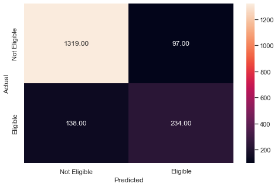

```python
# Checking performance on the testing data
# Remove _________ and complete the code

y_pred_test2 = dt.predict(X_test)

metrics_score(y_test, y_pred_test2)
```

**Insights

- Observations:Precision, recall and F1 score are all 1.0 for training which stands for perfect performance in the classification model which is a high chance there's overfitting.
- The testing dataset doesn't match the training so this model needs revision.

### **Think about it:**

- Can we improve this model?
- How to get optimal parameters in order to get the best possible results?

### **Decision Tree - Hyperparameter Tuning**

- Hyperparameter tuning is tricky in the sense that **there is no direct way to calculate how a change in the hyperparameter value will reduce the loss of your model**, so we usually resort to experimentation. We'll use Grid search to perform hyperparameter tuning.
- **Grid search is a tuning technique that attempts to compute the optimum values of hyperparameters.**
- **It is an exhaustive search** that is performed on the specific parameter values of a model.
- The parameters of the estimator/model used to apply these methods are **optimized by cross-validated grid-search** over a parameter grid.

**Criterion {“gini”, “entropy”}**

The function to measure the quality of a split. Supported criteria are “gini” for the Gini impurity and “entropy” for the information gain.

**max_depth**

The maximum depth of the tree. If None, then nodes are expanded until all leaves are pure or until all leaves contain less than min_samples_split samples.

**min_samples_leaf**

The minimum number of samples is required to be at a leaf node. A split point at any depth will only be considered if it leaves at least min_samples_leaf training samples in each of the left and right branches. This may have the effect of smoothing the model, especially in regression.

You can learn about more Hyperpapameters on this link and try to tune them.

https://scikit-learn.org/stable/modules/generated/sklearn.tree.DecisionTreeClassifier.html

#### Using GridSearchCV for Hyperparameter tuning on the model

```python
# Choose the type of classifier.
# Remove _________ and complete the code

dtree_estimator = DecisionTreeClassifier(class_weight = {0: 0.2, 1: 0.8}, random_state = 1)

# Grid of parameters to choose from
parameters = {'max_depth': np.arange(3, 7),
              'criterion': ['gini', 'entropy'],
              'min_samples_leaf': [5, 10, 20, 25]
             }

# Type of scoring used to compare parameter combinations
scorer = metrics.make_scorer(recall_score, pos_label = 1)

# Run the grid search
gridCV = GridSearchCV(dtree_estimator, parameters, scoring = scorer, cv = 10)

# Fitting the grid search on the train data
gridCV = gridCV.fit(X_train, y_train)

# Set the classifier to the best combination of parameters
dtree_estimator = gridCV.best_estimator_

# Fit the best estimator to the data
dtree_estimator.fit(X_train, y_train)
```

```
DecisionTreeClassifier(class_weight={0: 0.2, 1: 0.8}, max_depth=3,
                       min_samples_leaf=25, random_state=1)
```

#### Checking the performance on the train dataset

```
              precision    recall  f1-score   support

           0       0.95      0.85      0.89      3355
           1       0.56      0.81      0.66       817

    accuracy                           0.84      4172
   macro avg       0.76      0.83      0.78      4172
weighted avg       0.87      0.84      0.85      4172
```

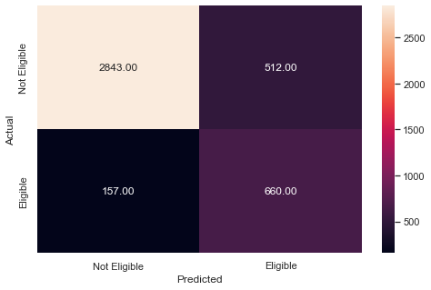

```python
# Checking performance on the training data based on the tuned model
# Remove _________ and complete the code

y_pred_train3 = dtree_estimator.predict(X_train)

metrics_score(y_train, y_pred_train3)
```

#### Checking the performance on the test dataset

```
              precision    recall  f1-score   support

           0       0.94      0.86      0.90      1416
           1       0.59      0.78      0.67       372

    accuracy                           0.84      1788
   macro avg       0.76      0.82      0.78      1788
weighted avg       0.86      0.84      0.85      1788
```

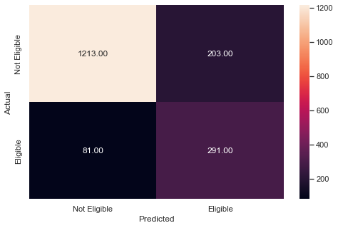

```python
# Checking performance on the testing data based on the tuned model
# Remove _________ and complete the code

y_pred_test3 = dtree_estimator.predict(X_test)

metrics_score(y_test, y_pred_test3)
```

**Insights

#### Plotting the Decision Tree

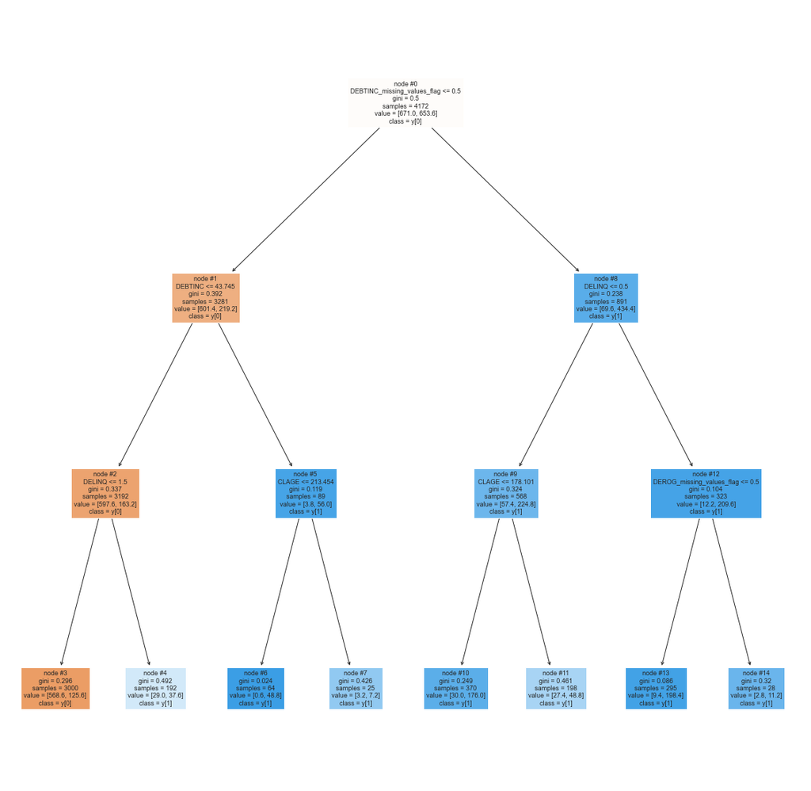

```python
# Plot the decision  tree and analyze it to build the decision rule
# Remove _________ and complete the code
features = list(X.columns)

plt.figure(figsize = (20, 20))

tree.plot_tree(dtree_estimator, feature_names = features, filled = True, fontsize = 9, node_ids = True, class_names = True)

plt.show()
```

### **Building a Random Forest Classifier**

**Random Forest is a bagging algorithm where the base models are Decision Trees.** Samples are taken from the training data and on each sample a decision tree makes a prediction.

**The results from all the decision trees are combined together and the final prediction is made using voting or averaging.**

```python
# Defining Random forest CLassifier
# Remove _________ and complete the code

rf = RandomForestClassifier(random_state = 7, criterion = "entropy")

rf.fit(X_train,y_train)
```

```
RandomForestClassifier(criterion='entropy', random_state=7)
```

#### Checking the performance on the train dataset

```python
#Checking performance on the training data
# Remove _________ and complete the code
y_pred_train4 = rf.predict(X_train)

metrics_score(y_train, y_pred_train4)
```

[output not shown]

```
              precision    recall  f1-score   support

           0       1.00      1.00      1.00      3355
           1       1.00      1.00      1.00       817

    accuracy                           1.00      4172
   macro avg       1.00      1.00      1.00      4172
weighted avg       1.00      1.00      1.00      4172
```

#### Checking the performance on the test dataset

```
              precision    recall  f1-score   support

           0       0.92      0.97      0.94      1416
           1       0.85      0.67      0.75       372

    accuracy                           0.91      1788
   macro avg       0.89      0.82      0.85      1788
weighted avg       0.91      0.91      0.90      1788
```

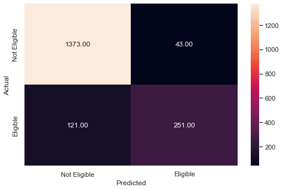

```python
# Checking performance on the test data
# Remove _________ and complete the code

y_pred_test4 = rf.predict(X_test)

metrics_score(y_test, y_pred_test4)
```

**Observations:

- The testing data is doing worse than the training data so there is some overfitting involved and the model needs a bit of tuning to fix this issue.

### **Build a Random Forest model with Class Weights**

```python
# Defining Random Forest model with class weights class_weight={0: 0.2, 1: 0.8}

# Remove _________ and complete the code

rf_weights = RandomForestClassifier(class_weight = {0: 0.2, 1: 0.8}, random_state = 1)

# Fitting Random Forest model
# Remove _________ and complete the code

rf_weights.fit(X_train, y_train)
```

```
RandomForestClassifier(class_weight={0: 0.2, 1: 0.8}, random_state=1)
```

#### Checking the performance on the train dataset

```python
# Checking performance on the train data
# Remove _________ and complete the code

y_pred_train5 = rf_weights.predict(X_train)

metrics_score(y_train, y_pred_train5)
```

[output not shown]

```
              precision    recall  f1-score   support

           0       1.00      1.00      1.00      3355
           1       1.00      1.00      1.00       817

    accuracy                           1.00      4172
   macro avg       1.00      1.00      1.00      4172
weighted avg       1.00      1.00      1.00      4172
```

#### Checking the performance on the test dataset

```
              precision    recall  f1-score   support

           0       0.92      0.97      0.94      1416
           1       0.86      0.67      0.75       372

    accuracy                           0.91      1788
   macro avg       0.89      0.82      0.85      1788
weighted avg       0.90      0.91      0.90      1788
```

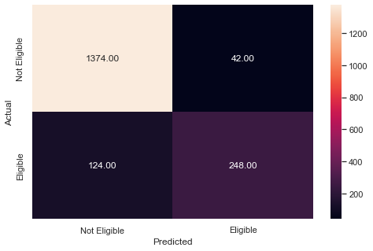

```python
# Checking performance on the test data
# Remove _________ and complete the code

y_pred_test5 = rf_weights.predict(X_test)

metrics_score(y_test, y_pred_test5)
```

### **Think about it:**

- Can we try different weights?
- If yes, should we increase or decrease class weights for different classes?

### **Tuning the Random Forest**

- Hyperparameter tuning is tricky in the sense that **there is no direct way to calculate how a change in the hyperparameter value will reduce the loss of your model**, so we usually resort to experimentation. We'll use Grid search to perform hyperparameter tuning.
- **Grid search is a tuning technique that attempts to compute the optimum values of hyperparameters.**
- **It is an exhaustive search** that is performed on the specific parameter values of a model.
- The parameters of the estimator/model used to apply these methods are **optimized by cross-validated grid-search** over a parameter grid.

**n_estimators**: The number of trees in the forest.

**min_samples_split**: The minimum number of samples required to split an internal node:

**min_samples_leaf**: The minimum number of samples required to be at a leaf node.

**max_features{“auto”, “sqrt”, “log2”, 'None'}**: The number of features to consider when looking for the best split.

- If “auto”, then max_features=sqrt(n_features).
- If “sqrt”, then max_features=sqrt(n_features) (same as “auto”).
- If “log2”, then max_features=log2(n_features).
- If None, then max_features=n_features.

You can learn more about Random Forest Hyperparameters from the link given below and try to tune them

https://scikit-learn.org/stable/modules/generated/sklearn.ensemble.RandomForestClassifier.html

#### **Warning:** This may take a long time depending on the parameters you tune.

```python
# Choose the type of classifier.
# Remove _________ and complete the code
rf_tuned = RandomForestClassifier(criterion = "entropy", random_state = 7)

# Grid of parameters to choose from
# Remove _________ and complete the code
parameters = {"n_estimators": [110, 120],
    "max_depth": [6, 7],
    "min_samples_leaf": [20, 25],
    "max_features": [0.8, 0.9],
    "max_samples": [0.9, 1],
    "class_weight": ["balanced",{0: 0.2, 1: 0.8}]
             }


# Type of scoring used to compare parameter combinations
# Remove _________ and complete the code
scorer = metrics.make_scorer(recall_score, pos_label = 1)

# Run the grid search
# Remove _________ and complete the code
grid_obj = GridSearchCV(rf_tuned, parameters, scoring = scorer, cv = 5)

#fit the GridSearch on train dataset
# Remove _________ and complete the code
grid_obj = grid_obj.fit(X_train, y_train)

# Set the clf to the best combination of parameters
# Remove _________ and complete the code
clf = grid_obj.best_estimator_

# Fit the best algorithm to the data.
# Remove _________ and complete the code
clf.fit(X_train, y_train)
```

```
RandomForestClassifier(class_weight='balanced', criterion='entropy',
                       max_depth=7, max_features=0.8, max_samples=0.9,
                       min_samples_leaf=20, n_estimators=110, random_state=7)
```

#### Checking the performance on the train dataset

```
              precision    recall  f1-score   support

           0       0.95      0.91      0.93      3355
           1       0.69      0.81      0.74       817

    accuracy                           0.89      4172
   macro avg       0.82      0.86      0.84      4172
weighted avg       0.90      0.89      0.89      4172
```

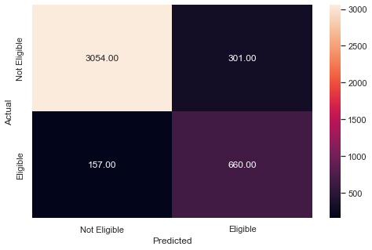

```python
# Checking performance on the training data
# Remove _________ and complete the code
y_pred_train5 = clf.predict(X_train)

metrics_score(y_train, y_pred_train5)
```

#### Checking the performance on the test dataset

```
              precision    recall  f1-score   support

           0       0.93      0.91      0.92      1416
           1       0.69      0.76      0.72       372

    accuracy                           0.88      1788
   macro avg       0.81      0.83      0.82      1788
weighted avg       0.88      0.88      0.88      1788
```

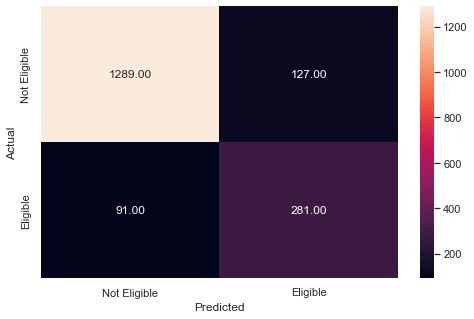

```python
# Checking performace on test dataset
# Remove _________ and complete the code

y_pred_test6 = clf.predict(X_test)

metrics_score(y_test, y_pred_test6)
```

#### Plot the Feature importance of the tuned Random Forest

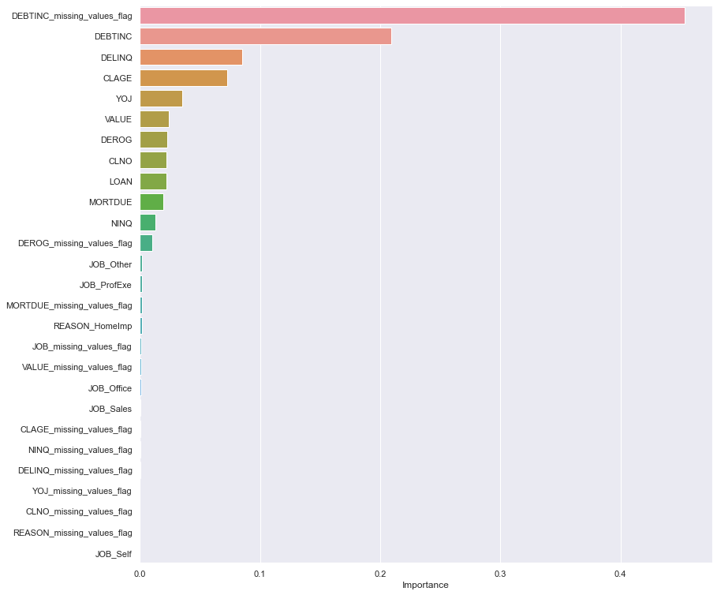

```python
# importance of features in the tree building ( The importance of a feature is computed as the
#(normalized) total reduction of the criterion brought by that feature. It is also known as the Gini importance )
# Checking performace on test dataset
# Remove _________ and complete the code


importances = clf.feature_importances_

columns = X.columns

importance_df = pd.DataFrame(importances, index = columns, columns = ['Importance']).sort_values(by = 'Importance', ascending = False)

plt.figure(figsize = (13, 13))

sns.barplot(importance_df.Importance, importance_df.index)
```

Insights:

```
- The model seems to suggest that DEBTINC, DELINQ, CLAGE are the top important features along with a few others
```

### **Think about it:**

- We have only built 3 models so far, Logistic Regression, Decision Tree and Random Forest
- We can build other Machine Learning classification models like kNN, LDA, QDA or even Support Vector Machines (SVM).
- Can we also perform feature engineering and create model features and build a more robust and accurate model for this problem statement?

### **Comparing Model Performances**

```python
def get_recall_score(model,flag=True,X_train=X_train,X_test=X_test):
    '''
    model : classifier to predict values of X

    '''
    a = [] # defining an empty list to store train and test results
    pred_train = model.predict(X_train)
    pred_test = model.predict(X_test)
    train_recall = metrics.recall_score(y_train,pred_train)
    test_recall = metrics.recall_score(y_test,pred_test)
    a.append(train_recall) # adding train recall to list
    a.append(test_recall) # adding test recall to list

    # If the flag is set to True then only the following print statements will be dispayed. The default value is set to True.
    if flag == True:
        print("Recall on training set : ",metrics.recall_score(y_train,pred_train))
        print("Recall on test set : ",metrics.recall_score(y_test,pred_test))

    return a # returning the list with train and test scores
```

```python
##  Function to calculate precision score
def get_precision_score(model,flag=True,X_train=X_train,X_test=X_test):
    '''
    model : classifier to predict values of X

    '''
    b = []  # defining an empty list to store train and test results
    pred_train = model.predict(X_train)
    pred_test = model.predict(X_test)
    train_precision = metrics.precision_score(y_train,pred_train)
    test_precision = metrics.precision_score(y_test,pred_test)
    b.append(train_precision) # adding train precision to list
    b.append(test_precision) # adding test precision to list

    # If the flag is set to True then only the following print statements will be dispayed. The default value is set to True.
    if flag == True:
        print("Precision on training set : ",metrics.precision_score(y_train,pred_train))
        print("Precision on test set : ",metrics.precision_score(y_test,pred_test))

    return b # returning the list with train and test scores
```

```python
##  Function to calculate accuracy score
def get_accuracy_score(model,flag=True,X_train=X_train,X_test=X_test):
    '''
    model : classifier to predict values of X

    '''
    c = [] # defining an empty list to store train and test results
    train_acc = model.score(X_train,y_train)
    test_acc = model.score(X_test,y_test)
    c.append(train_acc) # adding train accuracy to list
    c.append(test_acc) # adding test accuracy to list

    # If the flag is set to True then only the following print statements will be dispayed. The default value is set to True.
    if flag == True:
        print("Accuracy on training set : ",model.score(X_train,y_train))
        print("Accuracy on test set : ",model.score(X_test,y_test))

    return c # returning the list with train and test scores
```

```python
# Make the list of all the model names

models = [lg, dt, dtree_estimator, rf, rf_weights, clf]
# Remove _________ and complete the code

# defining empty lists to add train and test results
acc_train = []
acc_test = []
recall_train = []
recall_test = []
precision_train = []
precision_test = []

# looping through all the models to get the accuracy,recall and precision scores
for model in models:
     # accuracy score
    j = get_accuracy_score(model,False)
    acc_train.append(j[0])
    acc_test.append(j[1])

    # recall score
    k = get_recall_score(model,False)
    recall_train.append(k[0])
    recall_test.append(k[1])

    # precision score
    l = get_precision_score(model,False)
    precision_train.append(l[0])
    precision_test.append(l[1])
```

```python
# Mention the Model names in the list. for example 'Model': ['Decision Tree', 'Tuned Decision Tree'..... write tht names of all model built]
# Remove _________ and complete the code

comparison_frame = pd.DataFrame({'Model':['Log Regression', 'Decision Tree', 'Tuned Decision Tree', 'Random Forest', 'Weighted Random Forest','Tuned Random Forest'],
                                          'Train_Accuracy': acc_train,
                                          'Test_Accuracy': acc_test,
                                          'Train_Recall': recall_train,
                                          'Test_Recall': recall_test,
                                          'Train_Precision': precision_train,
                                          'Test_Precision': precision_test})
comparison_frame
```

|  | Model | Train_Accuracy | Test_Accuracy | Train_Recall | Test_Recall | Train_Precision | Test_Precision |
| --- | --- | --- | --- | --- | --- | --- | --- |
| 0 | Log Regression | 0.811361 | 0.800336 | 0.082007 | 0.077957 | 0.644231 | 0.674419 |
| 1 | Decision Tree | 1.000000 | 0.868568 | 1.000000 | 0.629032 | 1.000000 | 0.706949 |
| 2 | Tuned Decision Tree | 0.839645 | 0.841163 | 0.807834 | 0.782258 | 0.563140 | 0.589069 |
| 3 | Random Forest | 1.000000 | 0.908277 | 1.000000 | 0.674731 | 1.000000 | 0.853741 |
| 4 | Weighted Random Forest | 1.000000 | 0.907159 | 1.000000 | 0.666667 | 1.000000 | 0.855172 |
| 5 | Tuned Random Forest | 0.890221 | 0.878076 | 0.807834 | 0.755376 | 0.686785 | 0.688725 |

**Insights:

**1. Refined insights -** What are the most meaningful insights from the data relevant to the problem?

**2. Comparison of various techniques and their relative performance -** How do different techniques perform? Which one is performing relatively better? Is there scope to improve the performance further?

**3. Proposal for the final solution design -** What model do you propose to be adopted? Why is this the best solution to adopt?